# Introduction to Electrodynamics

### Dr. Ir Marzuki Sinambela, S.Kom, M.T

## 2. 1 Persamaan diferensial Maxwell dalam domain waktu

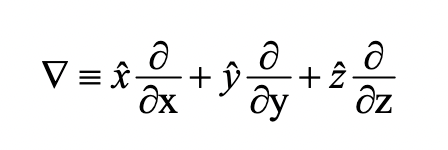

di mana x̂, ŷ, dan ẑ didefinisikan sebagai vektor satuan dalam koordinat Kartesius. Relasi yang melibatkan ∇ dirangkum dalam Lampiran D.

Di sini kita menggunakan operasi vektor yang umum, yaitu hasil kali titik (dot product) dan hasil kali silang (cross product) dari ∇ dengan vektor medan listrik dan medan magnet, misalnya:

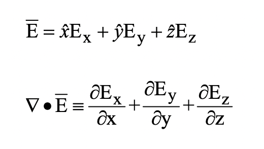

Kita menyebut ∇ • E sebagai divergen E karena besaran ini mengukur sejauh mana medan vektor E menyebar atau mengalir ke luar dari setiap titik. Hasil kali silang didefinisikan sebagai:

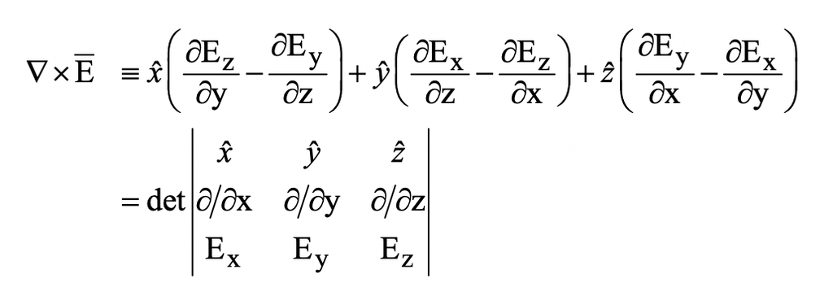

yang sering disebut rotasi dari E. Gambar 2.1 menunjukkan kapan divergen dan rotasi bernilai nol atau tidak nol untuk lima distribusi medan yang representatif

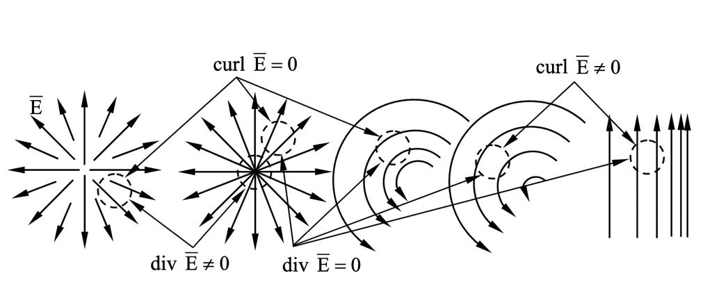

Gambar 2.1 Medan dengan divergen atau rotasi nol atau tidak nol.

Gambar tersebut menggambarkan perbedaan sifat medan listrik **E** berdasarkan nilai divergensi (div) dan rotasi (curl)-nya.

Di bagian kiri, medan listrik memancar keluar dari suatu titik (sumber muatan). Ini menunjukkan **div E ≠ 0** karena ada sumber (muatan listrik), tetapi **curl E = 0**, artinya medan tidak berputar dan bersifat konservatif seperti medan elektrostatik.

Di bagian kanan, garis medan membentuk pola melingkar, menunjukkan adanya rotasi sehingga **curl E ≠ 0**. Namun, tidak ada sumber atau muatan (**div E = 0**). Kondisi ini biasanya muncul pada medan listrik yang diinduksi oleh perubahan medan magnet (sesuai hukum Faraday).

### Kesimpulan

- **Divergensi** berkaitan dengan sumber atau muatan.
- **Curl** berkaitan dengan sifat perputaran medan.

Bentuk diferensial persamaan Maxwell dalam domain waktu adalah:

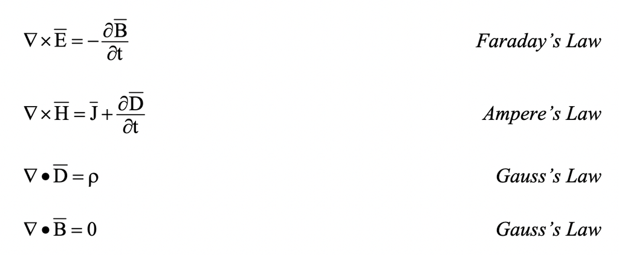

Variabel lapangan didefinisikan sebagai:

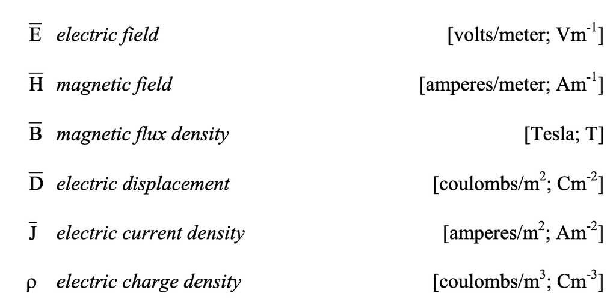

Keempat persamaan Maxwell ini melibatkan satu besaran skalar dan lima besaran vektor yang terdiri dari 16 variabel. Beberapa variabel hanya menggambarkan bagaimana materi memengaruhi perilaku medan, sebagaimana akan dibahas pada berikutnya. Dalam ruang hampa, kita dapat menghilangkan tiga vektor (9 variabel) dengan memperhatikan bahwa:

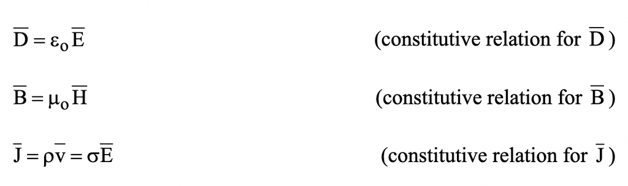

di mana ε₀ = 8.8542×10⁻¹² [farad m⁻¹] adalah permitivitas vakum, μ₀ = 4π×10⁻⁷ [henry m⁻¹] adalah permeabilitas vakum, v adalah kecepatan dari rapat muatan bersih lokal ρ, dan σ adalah konduktivitas suatu medium [siemens m⁻¹].

Jika kita menganggap sumber listrik ρ dan J sebagai besaran yang diketahui, maka persamaan-persamaan tersebut dapat diselesaikan untuk semua besaran tak diketahui lainnya. Secara khusus, kita dapat menentukan medan listrik E dan medan magnet H, dan dengan demikian menghitung gaya pada semua muatan yang ada.

Kecuali untuk kasus-kasus khusus, kita akan menghindari penyelesaian masalah di mana medan elektromagnetik dan pergerakan ρ saling bergantung satu sama lain.

Relasi konstitutif untuk vakum, D = ε₀E dan B = μ₀H, dapat digeneralisasi menjadi  
D = εE, B = μH, dan J = σE untuk medium sederhana. Medium akan dibahas lebih lanjut pada Bagian 2.5.

Persamaan Maxwell mensyaratkan kekekalan muatan. Dengan mengambil divergensi dari hukum Ampere dan menggunakan identitas vektor ∇ • (∇ × A) = 0, diperoleh:

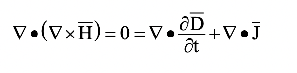

Kemudian, dengan membalik urutan turunan pada persaman diatas dan mensubstitusikan hukum Gauss ∇ • D = ρ , diperoleh bentuk diferensial dari kekekalan muatan:

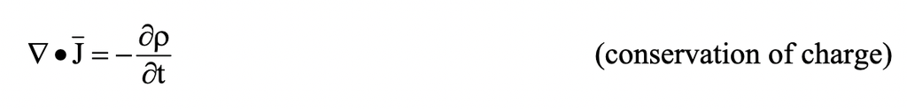

Bentuk integral dapat diturunkan dari bentuk diferensial dengan menggunakan teorema divergensi Gauss, yang menghubungkan integral dari ∇ • G pada suatu volume V dengan integral dari G • n̂ pada luas permukaan A yang membatasi volume tersebut, di mana vektor satuan normal permukaan n̂ mengarah ke luar:

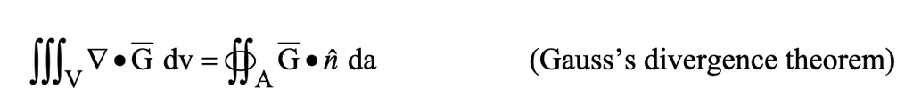

Dengan demikian, rumus integral untuk hukum kekekalan muatan adalah:

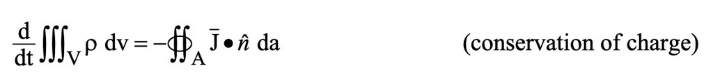

yang menyatakan bahwa jika tidak ada arus bersih (J) yang mengalir melalui permukaan A dari suatu volume V, maka total muatan di dalamnya harus tetap konstan.

# Contoh 2.1A

Jika medan listrik di vakum adalah  
E = x̂ E₀ cos(ωt − ky), berapakah H?

## Solusi

Dari hukum Faraday (2.1.5): μ₀ (∂H/∂t) = −(∇ × E)

= ẑ ∂Eₓ/∂y  
= ẑ kE₀ sin(ωt − ky),

dengan menggunakan (2.1.4) untuk operator curl.

Dengan mengintegralkan persamaan ini terhadap waktu diperoleh:

H = −ẑ (kE₀ / μ₀ω) cos(ωt − ky)

# Contoh 2.1B

Apakah medan listrik di vakum  
E = x̂ E₀ cos(ωt − kx) memenuhi persamaan Maxwell?  
Dalam kondisi apa medan E ini memenuhi persamaan tersebut?

## Solusi

Medan listrik ini tidak memenuhi hukum Gauss untuk vakum, yang mensyaratkan:

∇ • D = ρ = 0

Namun, medan ini hanya memenuhi hukum Gauss jika terdapat rapat muatan yang tidak nol:

ρ = ∇ • D  
= ε₀ ∂Eₓ/∂x  
= ∂[ε₀ E₀ cos(ωt − kx)]/∂x  
= kε₀E₀ sin(ωt − kx) ≠ 0

Agar memenuhi persamaan Maxwell lainnya dan hukum kekekalan muatan (2.1.19), harus terdapat arus:

J ≠ 0

yang berkaitan dengan ρ, yaitu:

J = σE  
= x̂ σE₀ cos(ωt − kx)

di mana persamaan (2.1.17) digunakan untuk menyederhanakan perhitungan.

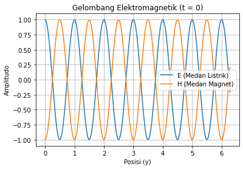

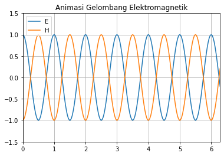

```python
# IMPORT LIBRARY

import numpy as np
import matplotlib.pyplot as plt
from matplotlib.animation import FuncAnimation

# PARAMETER GELOMBANG

E0 = 1.0          # amplitudo medan listrik
k = 2*np.pi       # bilangan gelombang
w = 2*np.pi       # frekuensi sudut
mu0 = 1.0         # konstanta (disederhanakan)

# Ruang dan waktu
y = np.linspace(0, 2*np.pi, 200)
t = 0

# =========================
# CONTOH 2.1A
# E = x̂ E0 cos(ωt − ky)
# H = −ẑ (kE0 / μ0ω) cos(ωt − ky)
# =========================

def E_field(y, t):
    return E0 * np.cos(w*t - k*y)

def H_field(y, t):
    return -(k*E0/(mu0*w)) * np.cos(w*t - k*y)

# =========================
# VISUALISASI STATIS
# =========================
plt.figure()

plt.plot(y, E_field(y, 0), label="E (Medan Listrik)")
plt.plot(y, H_field(y, 0), label="H (Medan Magnet)")

plt.title("Gelombang Elektromagnetik (t = 0)")
plt.xlabel("Posisi (y)")
plt.ylabel("Amplitudo")
plt.legend()
plt.grid()

plt.show()

# =========================
# ANIMASI GELOMBANG EM
# =========================

fig, ax = plt.subplots()
line_E, = ax.plot(y, E_field(y, 0), label="E")
line_H, = ax.plot(y, H_field(y, 0), label="H")

ax.set_ylim(-1.5, 1.5)
ax.set_xlim(0, 2*np.pi)
ax.set_title("Animasi Gelombang Elektromagnetik")
ax.legend()
ax.grid()

def update(frame):
    t = frame * 0.05
    line_E.set_ydata(E_field(y, t))
    line_H.set_ydata(H_field(y, t))
    return line_E, line_H

ani = FuncAnimation(fig, update, frames=200, interval=50)

plt.show()
```

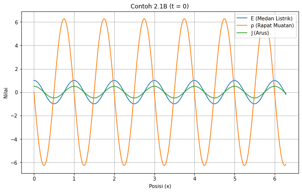

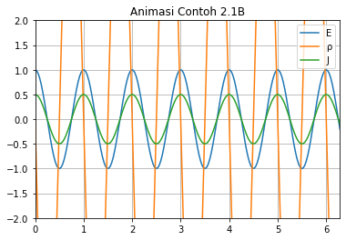

```python
# =========================
# IMPORT LIBRARY
# =========================
import numpy as np
import matplotlib.pyplot as plt
from matplotlib.animation import FuncAnimation

# =========================
# PARAMETER
# =========================
E0 = 1.0          # amplitudo medan listrik
k = 2*np.pi       # bilangan gelombang
w = 2*np.pi       # frekuensi sudut
eps0 = 1.0        # permitivitas (disederhanakan)
sigma = 0.5       # konduktivitas

# Ruang dan waktu
x = np.linspace(0, 2*np.pi, 200)

# =========================
# DEFINISI MEDAN
# E = x̂ E0 cos(ωt − kx)
# =========================
def E_field(x, t):
    return E0 * np.cos(w*t - k*x)

# =========================
# RHO = ∇·D = ε0 dEx/dx
# =========================
def rho(x, t):
    return eps0 * k * E0 * np.sin(w*t - k*x)

# =========================
# ARUS J = σE
# =========================
def J(x, t):
    return sigma * E_field(x, t)

# =========================
# VISUALISASI STATIS
# =========================
t0 = 0

plt.figure(figsize=(10,6))

plt.plot(x, E_field(x, t0), label="E (Medan Listrik)")
plt.plot(x, rho(x, t0), label="ρ (Rapat Muatan)")
plt.plot(x, J(x, t0), label="J (Arus)")

plt.title("Contoh 2.1B (t = 0)")
plt.xlabel("Posisi (x)")
plt.ylabel("Nilai")
plt.legend()
plt.grid()

plt.show()

# =========================
# ANIMASI
# =========================
fig, ax = plt.subplots()

line_E, = ax.plot(x, E_field(x, 0), label="E")
line_rho, = ax.plot(x, rho(x, 0), label="ρ")
line_J, = ax.plot(x, J(x, 0), label="J")

ax.set_ylim(-2, 2)
ax.set_xlim(0, 2*np.pi)
ax.set_title("Animasi Contoh 2.1B")
ax.legend()
ax.grid()

def update(frame):
    t = frame * 0.05
    line_E.set_ydata(E_field(x, t))
    line_rho.set_ydata(rho(x, t))
    line_J.set_ydata(J(x, t))
    return line_E, line_rho, line_J

ani = FuncAnimation(fig, update, frames=200, interval=50)

plt.show()
```

## 2.2 Gelombang elektromagnetik dalam domain waktu

Mungkin pencapaian terbesar dari persamaan Maxwell adalah kemampuannya untuk memprediksi secara sederhana keberadaan dan kecepatan gelombang elektromagnetik berdasarkan pengukuran sederhana di laboratorium terhadap permitivitas dan permeabilitas vakum.

Di dalam vakum, rapat muatan ρ = 0 dan arus J = 0, sehingga persamaan Maxwell menjadi:

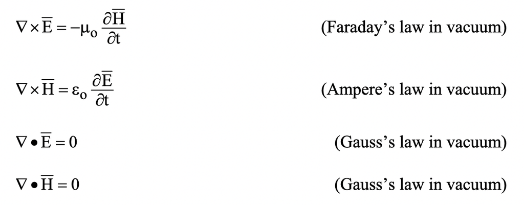

Kita dapat mengeliminasi H dari persamaan-persamaan ini dengan menghitung curl dari hukum Faraday, yang menghasilkan suku ∇ × H pada ruas kanan sehingga hukum Ampere dapat disubstitusikan:

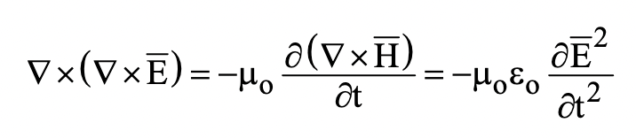

Menggunakan identitas vektor yang terkenal

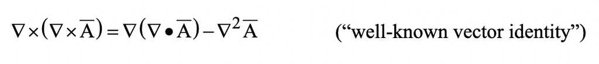

dan kemudian dengan menggunakan (2.2.3) untuk mengeliminasi ∇ • E, maka (2.2.5) menjadi persamaan gelombang elektromagnetik, yang sering disebut sebagai persamaan gelombang Helmholtz

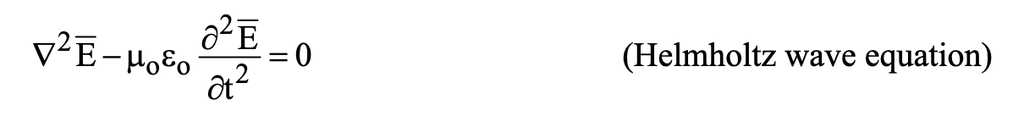

dimana:

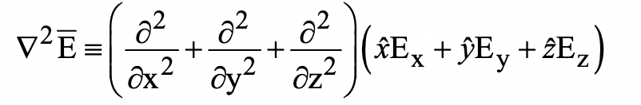

Solusi dari persamaan gelombang ini (2.2.7) adalah semua medan E(r, t) yang memenuhi bahwa turunan spasial orde kedua (∇²E) sama dengan suatu konstanta dikalikan turunan waktu orde kedua.

Vektor posisi didefinisikan sebagai: r ≡ x̂x + ŷy + ẑz.

Dengan demikian, persamaan gelombang dipenuhi oleh setiap E(r, t) yang memiliki ketergantungan yang sama terhadap ruang dan waktu, hingga suatu faktor pengali konstan.

Sebagai contoh, fungsi sembarang dengan argumen (z − ct), (z + ct), atau (t ± z/c) memiliki ketergantungan seperti itu dan merupakan solusi yang valid dari (2.2.7), di mana c adalah suatu konstanta yang akan ditentukan.

Salah satu solusi tersebut adalah:

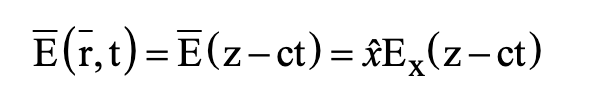

di mana fungsi sembarang Ex(z − ct) dapat berupa seperti yang ditunjukkan pada Gambar 2.2 pada waktu t = 0 dan kembali pada suatu waktu t yang lebih kemudian.

Perhatikan bahwa seiring waktu bertambah dalam argumen (z − ct), nilai z juga harus bertambah sebesar ct agar argumen tersebut, atau nilai E pada setiap titik tertentu pada bentuk gelombang, tetap konstan.

### Gelombang elektromagnetik sembarang yang merambat ke arah +z.

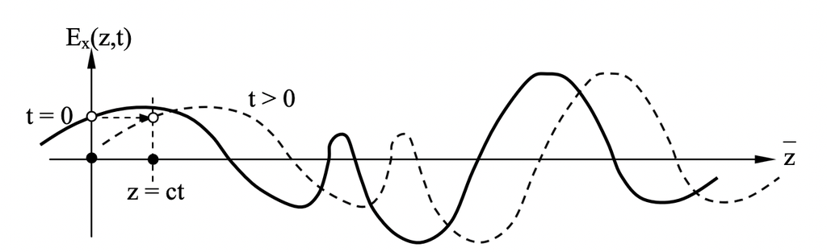

Gambar tersebut menunjukkan perambatan gelombang medan listrik Ex(z, t) sepanjang sumbu z.

Pada waktu t = 0, bentuk gelombang digambarkan dengan garis penuh. Ketika waktu bertambah (t > 0), gelombang bergeser ke arah kanan (arah +z), yang ditunjukkan oleh garis putus-putus.

Perpindahan gelombang ini mengikuti hubungan z = ct, yang berarti gelombang merambat dengan kecepatan c. Dengan kata lain, setiap titik pada gelombang mempertahankan bentuknya, namun berpindah posisi sejauh ct seiring bertambahnya waktu.

Hal ini menunjukkan bahwa fungsi gelombang bergantung pada (z − ct), yang merupakan ciri gelombang berjalan ke arah positif sumbu z tanpa perubahan bentuk.

### Contoh 2.2A

Tunjukkan bahwa medan listrik  
E = ŷ E₀ (t + z/c) memenuhi persamaan gelombang (2.2.7).  
Ke arah mana gelombang ini merambat?

#### Solusi

Substitusikan E ke dalam persamaan gelombang:

(∇² − (1/c²) ∂²/∂t²) E  
= ŷ (1/c²) [E₀''(t + z/c) − E₀''(t + z/c)]  
= 0

Sehingga persamaan gelombang terpenuhi (Q.E.D).

Karena argumen (t + z/c) tetap konstan hanya jika nilai z/c berkurang saat t bertambah, maka gelombang tersebut merambat ke arah **−z**.

#### Kesimpulan

- Fungsi E = ŷ E₀ (t + z/c) adalah solusi persamaan gelombang.
- Gelombang merambat ke arah **negatif sumbu z (−z)**.

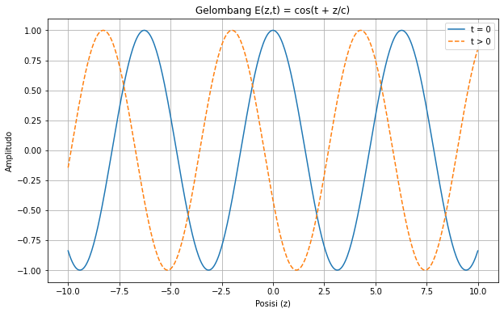

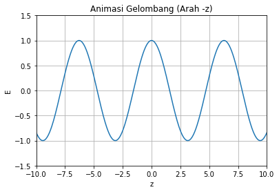

```python
# =========================
# IMPORT LIBRARY
# =========================
import numpy as np
import matplotlib.pyplot as plt
from matplotlib.animation import FuncAnimation

# =========================
# PARAMETER
# =========================
E0 = 1.0
c = 1.0

# Domain ruang dan waktu
z = np.linspace(-10, 10, 400)

# =========================
# DEFINISI GELOMBANG
# E = E0 (t + z/c)
# contoh fungsi: cos(t + z/c)
# =========================
def E_field(z, t):
    return E0 * np.cos(t + z/c)

# =========================
# VISUALISASI STATIS
# =========================
t0 = 0
t1 = 2

plt.figure(figsize=(10,6))

plt.plot(z, E_field(z, t0), label="t = 0")
plt.plot(z, E_field(z, t1), '--', label="t > 0")

plt.title("Gelombang E(z,t) = cos(t + z/c)")
plt.xlabel("Posisi (z)")
plt.ylabel("Amplitudo")
plt.legend()
plt.grid()

plt.show()

# =========================
# ANIMASI GELOMBANG
# =========================
fig, ax = plt.subplots()

line, = ax.plot(z, E_field(z, 0))

ax.set_ylim(-1.5, 1.5)
ax.set_xlim(-10, 10)
ax.set_title("Animasi Gelombang (Arah -z)")
ax.set_xlabel("z")
ax.set_ylabel("E")

ax.grid()

def update(frame):
    t = frame * 0.1
    line.set_ydata(E_field(z, t))
    return line,

ani = FuncAnimation(fig, update, frames=200, interval=50)

plt.show()
```